# Predicting heart disease with classification trees

Jeremy Locatelli

April 23, 2017

### **Reading and preprocessing the data**

Lets get our data into a table and set up all our labels so they are a bit easier to work with.

```r
> heart = read.table("https://raw.githubusercontent.com/grbruns/cst383/master/heart.dat", quote = "/")
> names(heart) <- c("AGE", "SEX", "CHESTPAIN", "RESTBP", "CHOL",
+                   "SUGAR", "ECG", "MAXHR", "ANGINA", "DEP", "EXERCISE", "FLUOR",
+                   "THAL", "OUTPUT")
> names(heart) = tolower(names(heart))
>
> # convert output to factor
> heart$output = factor(heart$output, labels=c("ok", "disease"))
> str(heart)
```

```
'data.frame':   270 obs. of  14 variables:
 $ age      : num  70 67 57 64 74 65 56 59 60 63 ...
 $ sex      : num  1 0 1 1 0 1 1 1 1 0 ...
 $ chestpain: num  4 3 2 4 2 4 3 4 4 4 ...
 $ restbp   : num  130 115 124 128 120 120 130 110 140 150 ...
 $ chol     : num  322 564 261 263 269 177 256 239 293 407 ...
 $ sugar    : num  0 0 0 0 0 0 1 0 0 0 ...
 $ ecg      : num  2 2 0 0 2 0 2 2 2 2 ...
 $ maxhr    : num  109 160 141 105 121 140 142 142 170 154 ...
 $ angina   : num  0 0 0 1 1 0 1 1 0 0 ...
 $ dep      : num  2.4 1.6 0.3 0.2 0.2 0.4 0.6 1.2 1.2 4 ...
 $ exercise : num  2 2 1 2 1 1 2 2 2 2 ...
 $ fluor    : num  3 0 0 1 1 0 1 1 2 3 ...
 $ thal     : num  3 7 7 7 3 7 6 7 7 7 ...
 $ output   : Factor w/ 2 levels "ok","disease": 2 1 2 1 1 1 2 2 2 2 ...
```

### **Data exploration**

I want to get a better idea of what our data looks like, we have a fairly small dataset of only 270 rows. I built a correlation plot to see what features i should keep an eye on. While most of the features have a fairly weak correlation, it looks like *dep* and *exercise* have a 0.61 corr value while *age* and *maxhr* have a -0.4 corr value so lets I’m interested to see how a model with those features fairs.

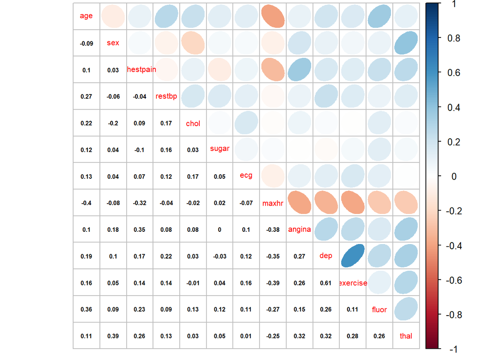

```r
> heart_num = heart[,1:13]
> corr = cor(heart_num)
> corrplot.mixed(corr,upper = "ellipse", lower.col = "black", number.cex = 0.5, tl.cex = 0.65)
```

### **Building the Classification Tree**

It looks like our most important features are *dep* and *maxhr* while *exercise* and *age* seem to be lower.

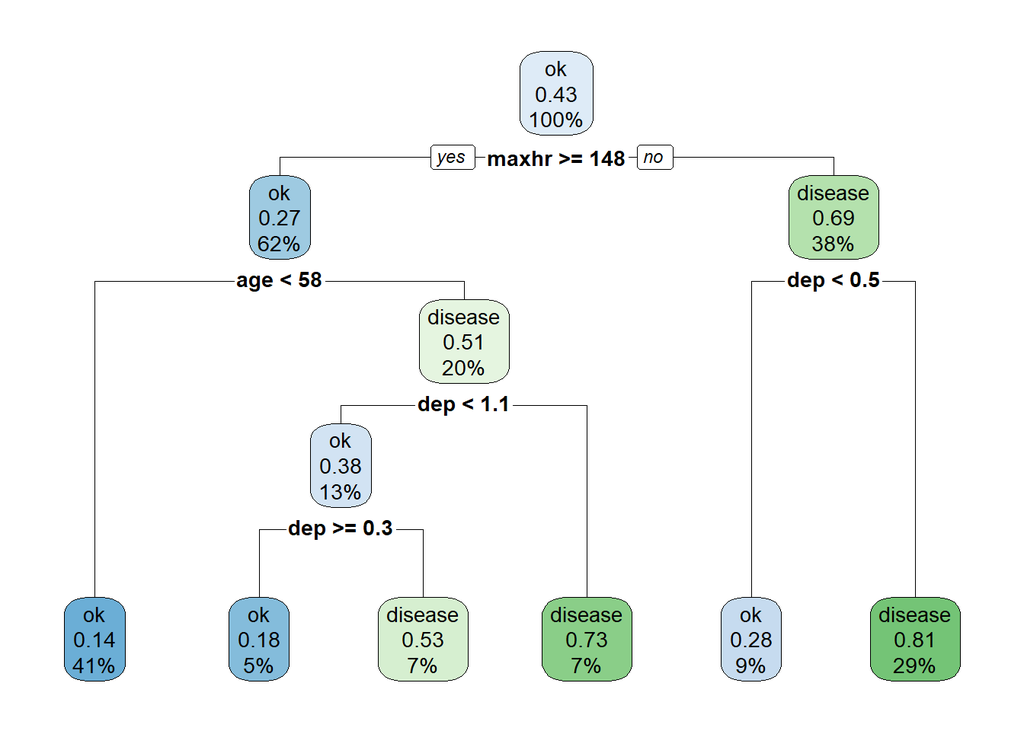

```r
> # training and test sets
> set.seed(132)
> split = split_data(heart)
> tr_dat = split[[1]]
> te_dat = split[[2]]
>
> fit = rpart(output ~ maxhr + dep + age + exercise, data = tr_dat)
> rpart.plot(fit)
```

### **Predicting with our model**

```r
> predicts1 = predict(fit, newdata = te_dat, type = "class")
>
> actuals1 = te_dat$output
> conf_matrix1 = table(predicts1,actuals1)
> conf_matrix1
```

```
         actuals1
predicts1 ok disease
  ok      25       9
  disease 10      25
```

```r
> accuracy = mean(actuals1 == predicts1)
> paste("The accuracy of model is",round(accuracy,3))
```

```
[1] "The accuracy of model is 0.725"
```

### **Building another model**

I want to try 2 different models, I’m interested in seeing how a model with every feature will compare to our current model, and I also want to see if using just the 2 most correlated features *dep* and *maxhr* and see how it fares.

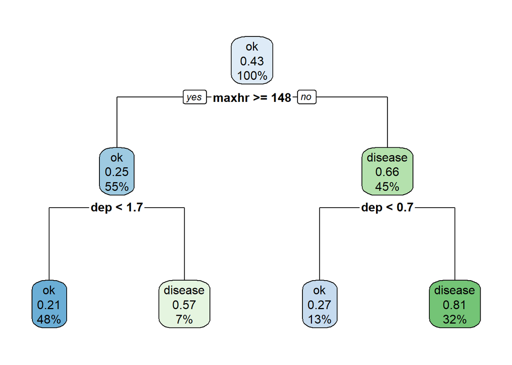

```r
> #First lets mix up the training and test sets
> #I want to try a 75/25 split this time
> set.seed(1086)
> splits2 = split_data(heart,c(0.75,0.25))
> tr_dat2 = splits2[[1]]
> te_dat2 = splits2[[2]]
>
> fit2 = rpart(output ~ dep + maxhr, data = tr_dat2)
> rpart.plot(fit2)
```

### Assessing Model 2

```r
> predicts2 = predict(fit2, newdata = te_dat, type = "class")
> actuals2 = te_dat2$output
>
> conf_mtx2 = table(actuals2,predicts2)
> conf_mtx2
```

```
         predicts2
actuals2  ok disease
  ok      18      18
  disease 21      12
```

```r
> accuracy2 = mean(actuals2==predicts2)
>
> paste("The accuracy of our model is",round(accuracy2,3))
```

```
[1] "The accuracy of our model is 0.435"
```

### …

That is really bad wow, even worse than just flipping a coin to predict. Lets tryand see iff our model with every feature is better or worse. Recall our orginal model with maxhr, dep, age, and exercise had an accuracy of 72.5%

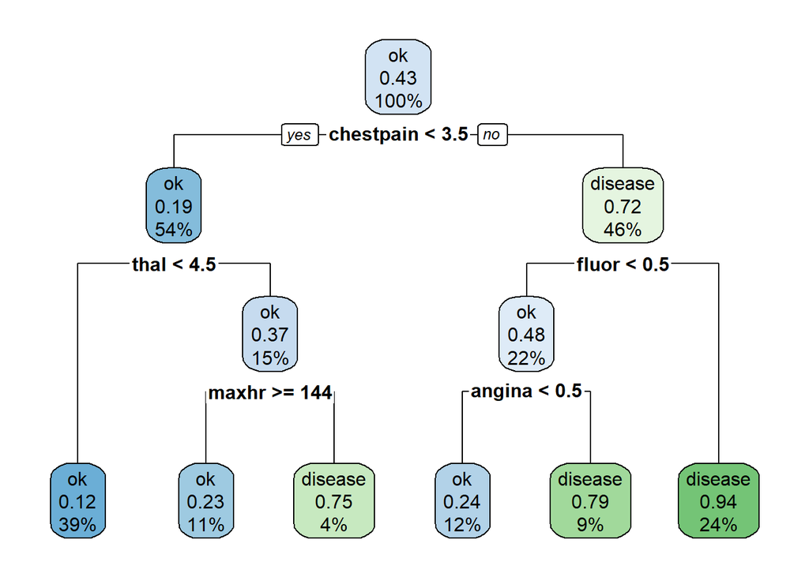

```r
> set.seed(489)
> splits3 = split_data(heart,c(0.75,0.25))
> tr_dat3 = splits3[[1]]
> te_dat3 = splits3[[2]]
>
> fit3 = rpart(output ~ ., data = tr_dat2)
> rpart.plot(fit3)
```

```r
> predicts3 = predict(fit3, newdata = te_dat3, type = "class")
> actuals3 = te_dat3$output
>
> conf_mtx3 = table(actuals3, predicts3)
> accuracy3 = mean(actuals3 == predicts3)
>
>
> paste("The accuracy of our model is",round(accuracy3,3))
```

```
[1] "The accuracy of our model is 0.826"
```